# Erreurs simulations débourrement SUWE

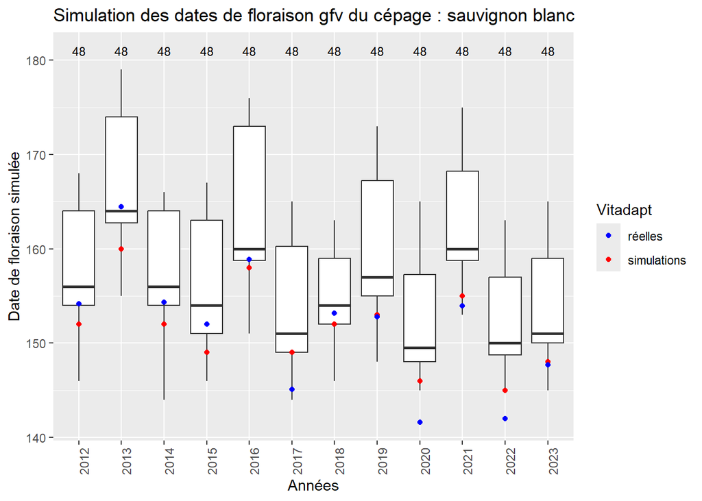

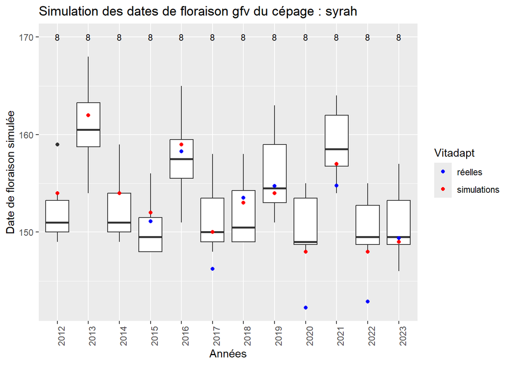

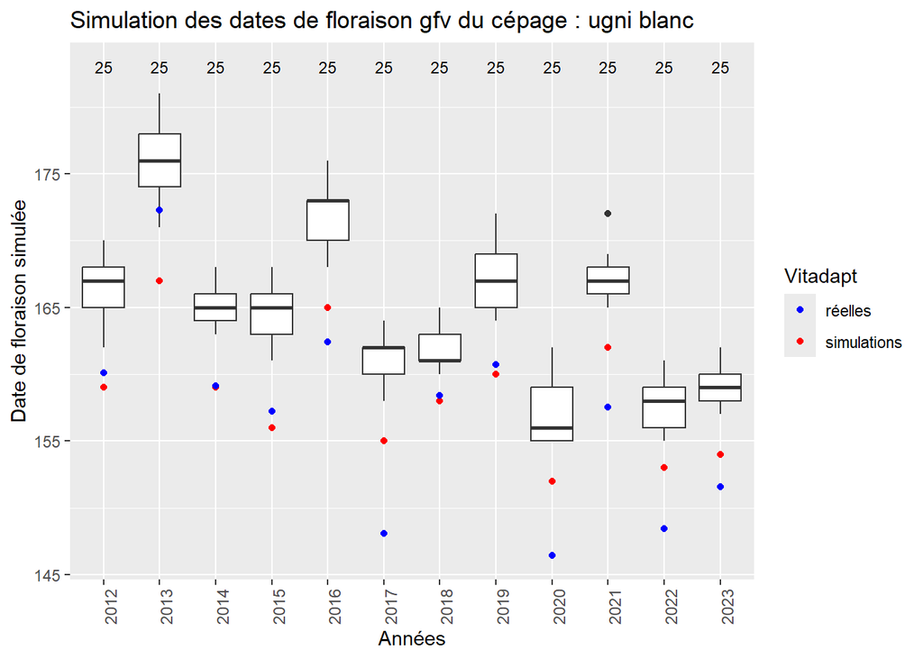

Peu importe le modèle, le stade phénologique simulé et le cépage, il existe un réel décalage entre les simulations sur les parcelles des producteurs et la parcelle vitadapt (simulations et observations), mais avec le modèle gfv les observations de floraison de la parcelle vitadapt sont plus proches des simulations sur cette parcelle que sur les autres.

On ne peut donc pas rejeter notre hypothèse selon laquelle la calibration des paramètres du modèle SUWE est faite sur des données où chaque cépage est dans les régions où on le retrouve habituellement, et donc le modèle aurait du mal à extrapoler sur de nouveaux couples régions / cépages.

-> A discuter : Sauf que pour le cabernet franc et le merlot on observe de grandes différences entre simulations vitadapt et observations vitadapt, or ces deux cépages sont présents dans la région bordelaise d’apèrs la carte page 39 de “Identification of ecoclimatic indicators of esca disease through 20 years of large-scale vineyard monitoring in France”.

Sur l’ensemble des parcelles, les années 2015 et 2022 ne semblent pas particulières, mais elles peuvent l’être sur la parcelle vitadapt.